```python
import pandas as pd #library for data manipulation and analysis
import numpy as np #library used for working with arrays
import matplotlib.pyplot as plt #library for plots and visualizations
import seaborn as sns #library for visualizations
from scipy.stats import norm #using normal distibutions


%matplotlib inline

import scipy.stats #library contains a number of probibility distributions and statistical functions
```

# INFERENTIAL STATISTICS

Simple random sample

Any item in the population has an equal chance of being selected

miu = population mean xbar = sample mean sigma = population standard deviation sigma/sqrt(n) = standard deviation of sample or standard deviation of xbar

SEED - A random seed (or seed state, or just seed) is a number (or vector) used to initialize a pseudorandom number generator. For a seed to be used in a pseudorandom number generator, it does not need to be random.

# Central Limit Theorem

The sampling distribution of the MEAN will ALWAYS be NORMALLY DISTRIBUTED as long as the SAMPLE size is largge enough. REGAURDLESS of wether the population is normally distributed, Poisson OR binomial etc. The SAMPLING distribution will always be normal

NOTE: smaller sample sizes of the population are okay as long as they are normal, but remember we have to make assumptions on the population from the sample size

The averaging of things, even when they are very skewed will result in a normal distribution

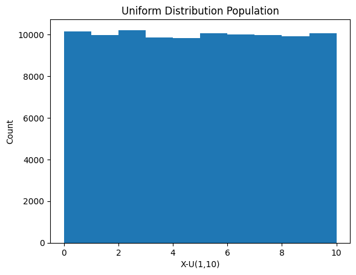

```python
from scipy.stats import uniform

#setting up the seed for reproducibility
np.random.seed(1)
#create a uniform distribution of size 100000
uniform_pop = uniform.rvs(0,10,size=100000)
#visualize the uniform distribution
plt.hist(uniform_pop)
plt.title("Uniform Distribution Population")
plt.xlabel("X-U(1,10)")
plt.ylabel("Count")
plt.show();
```

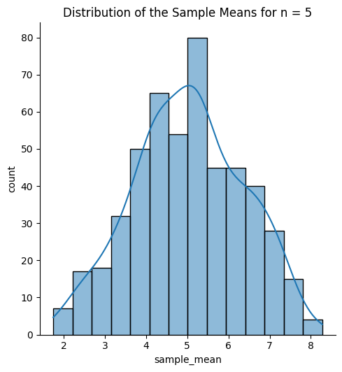

```python
"""

From this population we will sample to creat a sampling distribution of size 5,
with 500 samples


"""
#set the seed for reproducibility
np.random.seed(1)
#set the sample size to 5
n = 5
#list to store the sample means
sample_means = []

#iterate the loop to draw multiple samples
for j in range(500):
    #draw a sample size of n
    sample = np.random.choice(uniform_pop, size=n)
    #calculate the sample mean
    sample_mean = np.mean(sample)
    #append the sample mean to the sample_means list
    sample_means.append(sample_mean)
#plot the histogram
sns.displot(sample_means, kde=True)
plt.title("Distribution of the Sample Means for n = " + str(n))
plt.xlabel("sample_mean")
plt.ylabel("count")
plt.show()
```

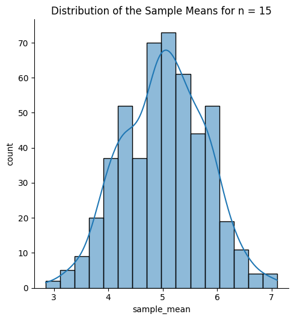

```python
"""

We will sample again with n = 15 observations
"""

#set the seed for reproducibility
np.random.seed(1)
#set the sample size to 15
n = 15
#list to store the sample means
sample_means = []

#iterate the loop to draw multiple samples
for j in range(500):
    #draw a sample size of n
    sample = np.random.choice(uniform_pop, size=n)
    #calculate the sample mean
    sample_mean = np.mean(sample)
    #append the sample mean to the sample_means list
    sample_means.append(sample_mean)
#plot the histogram
sns.displot(sample_means, kde=True)
plt.title("Distribution of the Sample Means for n = " + str(n))
plt.xlabel("sample_mean")
plt.ylabel("count")
plt.show()
```

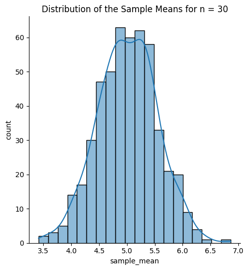

```python
"""

We will sample again with n = 30 observations
"""

#set the seed for reproducibility
np.random.seed(1)
#set the sample size to 30
n = 30
#list to store the sample means
sample_means = []

#iterate the loop to draw multiple samples
for j in range(500):
    #draw a sample size of n
    sample = np.random.choice(uniform_pop, size=n)
    #calculate the sample mean
    sample_mean = np.mean(sample)
    #append the sample mean to the sample_means list
    sample_means.append(sample_mean)
#plot the histogram
sns.displot(sample_means, kde=True)
plt.title("Distribution of the Sample Means for n = " + str(n))
plt.xlabel("sample_mean")
plt.ylabel("count")
plt.show()
```

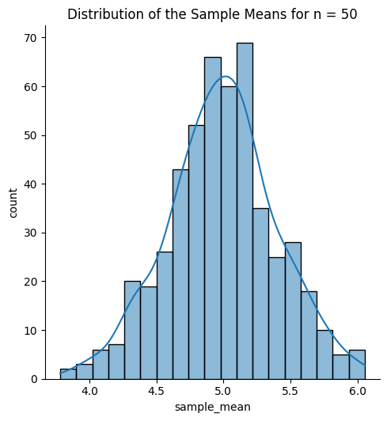

```python
"""

So we can see the larger the sample size the more normal the bell shape becomes

so lets go for n = 50

"""

#set the seed for reproducibility
np.random.seed(1)
#set the sample size to 50
n = 50
#list to store the sample means
sample_means = []

#iterate the loop to draw multiple samples
for j in range(500):
    #draw a sample size of n
    sample = np.random.choice(uniform_pop, size=n)
    #calculate the sample mean
    sample_mean = np.mean(sample)
    #append the sample mean to the sample_means list
    sample_means.append(sample_mean)
#plot the histogram
sns.displot(sample_means, kde=True)
plt.title("Distribution of the Sample Means for n = " + str(n))
plt.xlabel("sample_mean")
plt.ylabel("count")
plt.show()
```

```python
"""

So we can do testing on this sample size with the hopes that it will translate to the
population

We can infer info form this sample, like the mean = 5 etc for testing

"""
```

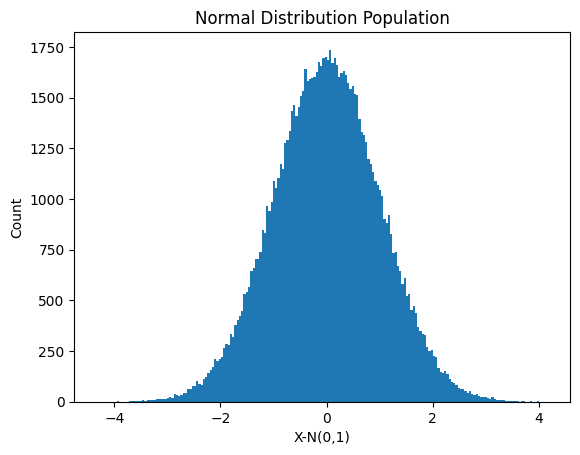

```python
"""

What happens when the population is normal?

"""

from scipy.stats import norm

#set the seed for reproducibility
np.random.seed(1)
#create a normal distribution population of 100000
#rvs = random variable serial
normal_pop = norm.rvs(0,1, size = 100000)
#visualize
plt.hist(normal_pop, 200)
plt.title("Normal Distribution Population")
plt.xlabel("X-N(0,1)")
plt.ylabel("Count")
plt.show();
```

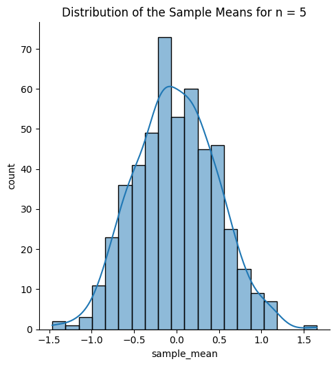

```python
"""

From this population we will sample to creat a sampling distribution of size 5,
with 500 samples


"""
#set the seed for reproducibility
np.random.seed(1)
#set the sample size to 5
n = 5
#list to store the sample means
sample_means = []

#iterate the loop to draw multiple samples
for j in range(500):
    #draw a sample size of n
    sample = np.random.choice(normal_pop, size=n)
    #calculate the sample mean
    sample_mean = np.mean(sample)
    #append the sample mean to the sample_means list
    sample_means.append(sample_mean)
#plot the histogram
sns.displot(sample_means, kde=True)
plt.title("Distribution of the Sample Means for n = " + str(n))
plt.xlabel("sample_mean")
plt.ylabel("count")
plt.show()
```

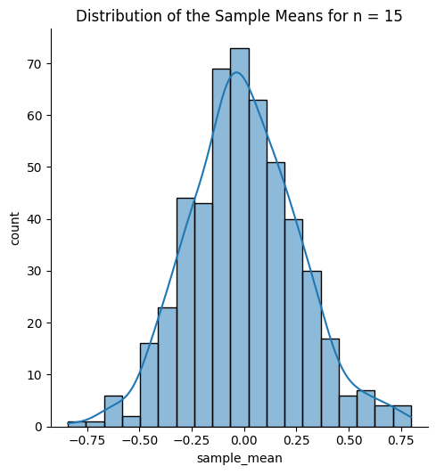

```python
"""

From this population we will sample to creat a sampling distribution of size 15,
with 500 samples


"""
#set the seed for reproducibility
np.random.seed(1)
#set the sample size to 15
n = 15
#list to store the sample means
sample_means = []

#iterate the loop to draw multiple samples
for j in range(500):
    #draw a sample size of n
    sample = np.random.choice(normal_pop, size=n)
    #calculate the sample mean
    sample_mean = np.mean(sample)
    #append the sample mean to the sample_means list
    sample_means.append(sample_mean)
#plot the histogram
sns.displot(sample_means, kde=True)
plt.title("Distribution of the Sample Means for n = " + str(n))
plt.xlabel("sample_mean")
plt.ylabel("count")
plt.show()
```

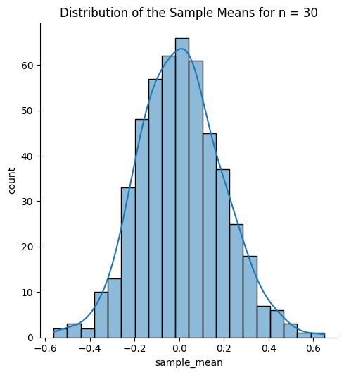

```python
"""

From this population we will sample to creat a sampling distribution of size 30,
with 500 samples


"""
#set the seed for reproducibility
np.random.seed(1)
#set the sample size to 30
n = 30
#list to store the sample means
sample_means = []

#iterate the loop to draw multiple samples
for j in range(500):
    #draw a sample size of n
    sample = np.random.choice(normal_pop, size=n)
    #calculate the sample mean
    sample_mean = np.mean(sample)
    #append the sample mean to the sample_means list
    sample_means.append(sample_mean)
#plot the histogram
sns.displot(sample_means, kde=True)
plt.title("Distribution of the Sample Means for n = " + str(n))
plt.xlabel("sample_mean")
plt.ylabel("count")
plt.show()
```

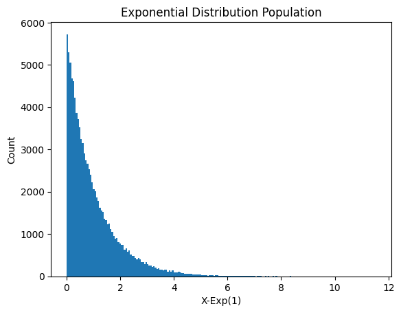

```python
"""

Here is an example of Extreme distribution

"""

from scipy.stats import expon

#set the seed for reproducibility
np.random.seed(1)
#create a normal distribution population of 100000
#rvs = random variable serial
exp_pop = expon.rvs(0,1, size = 100000)
#visualize
plt.hist(exp_pop, 200)
plt.title("Exponential Distribution Population")
plt.xlabel("X-Exp(1)")
plt.ylabel("Count")
plt.show();
```

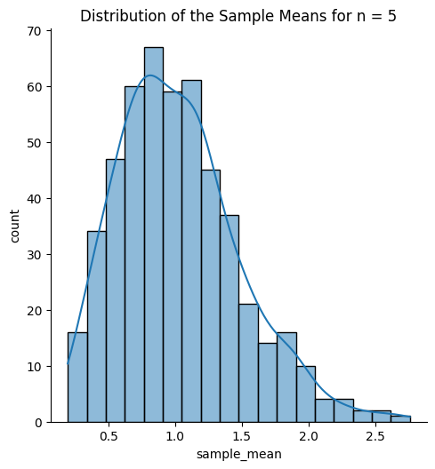

```python
"""

From this population we will sample to creat a sampling distribution of size 5,
with 500 samples


"""
#set the seed for reproducibility
np.random.seed(1)
#set the sample size to 5
n = 5
#list to store the sample means
sample_means = []

#iterate the loop to draw multiple samples
for j in range(500):
    #draw a sample size of n
    sample = np.random.choice(exp_pop, size=n)
    #calculate the sample mean
    sample_mean = np.mean(sample)
    #append the sample mean to the sample_means list
    sample_means.append(sample_mean)
#plot the histogram
sns.displot(sample_means, kde=True)
plt.title("Distribution of the Sample Means for n = " + str(n))
plt.xlabel("sample_mean")
plt.ylabel("count")
plt.show()
```

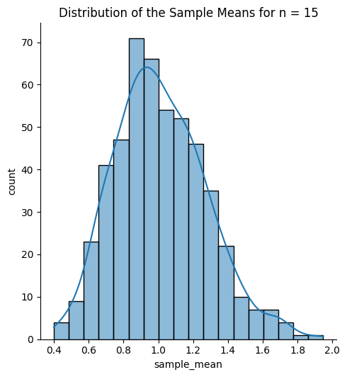

```python
"""

From this population we will sample to creat a sampling distribution of size 15,
with 500 samples


"""
#set the seed for reproducibility
np.random.seed(1)
#set the sample size to 15
n = 15
#list to store the sample means
sample_means = []

#iterate the loop to draw multiple samples
for j in range(500):
    #draw a sample size of n
    sample = np.random.choice(exp_pop, size=n)
    #calculate the sample mean
    sample_mean = np.mean(sample)
    #append the sample mean to the sample_means list
    sample_means.append(sample_mean)
#plot the histogram
sns.displot(sample_means, kde=True)
plt.title("Distribution of the Sample Means for n = " + str(n))
plt.xlabel("sample_mean")
plt.ylabel("count")
plt.show()
```

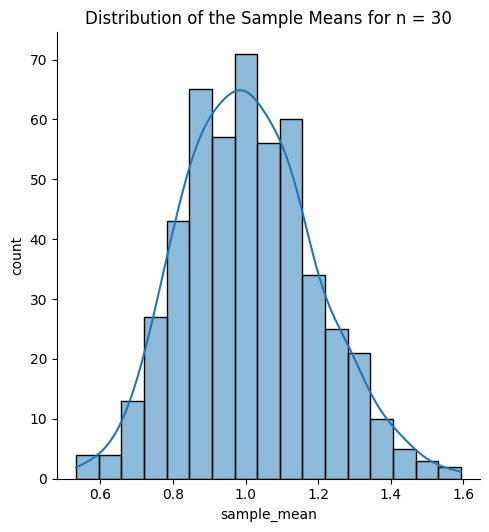

```python
"""

From this population we will sample to creat a sampling distribution of size 30,
with 500 samples


"""
#set the seed for reproducibility
np.random.seed(1)
#set the sample size to 30
n = 30
#list to store the sample means
sample_means = []

#iterate the loop to draw multiple samples
for j in range(500):
    #draw a sample size of n
    sample = np.random.choice(exp_pop, size=n)
    #calculate the sample mean
    sample_mean = np.mean(sample)
    #append the sample mean to the sample_means list
    sample_means.append(sample_mean)
#plot the histogram
sns.displot(sample_means, kde=True)
plt.title("Distribution of the Sample Means for n = " + str(n))
plt.xlabel("sample_mean")
plt.ylabel("count")
plt.show()
```

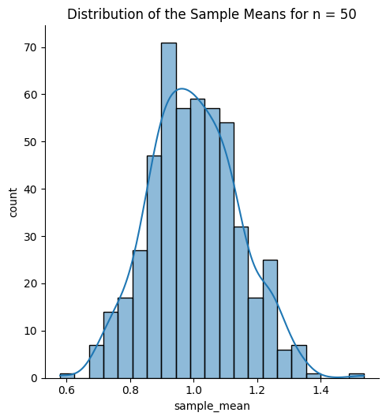

```python
"""

From this population we will sample to creat a sampling distribution of size 50,
with 500 samples


"""
#set the seed for reproducibility
np.random.seed(1)
#set the sample size to 50
n = 50
#list to store the sample means
sample_means = []

#iterate the loop to draw multiple samples
for j in range(500):
    #draw a sample size of n
    sample = np.random.choice(exp_pop, size=n)
    #calculate the sample mean
    sample_mean = np.mean(sample)
    #append the sample mean to the sample_means list
    sample_means.append(sample_mean)
#plot the histogram
sns.displot(sample_means, kde=True)
plt.title("Distribution of the Sample Means for n = " + str(n))
plt.xlabel("sample_mean")
plt.ylabel("count")
plt.show()
```

# Estimation

We can use the normalized sample to make estimations on th epopulation

2 types of estimations

1. Point estimation - single point estimation of the population parameter ex. population mean as estimates from sample is 40
2. Interval Estimation - a range of values within which the population parameter lies with some X% confidence ex. population mean should lie between 38 - 42 with a 95% confidence

Confidence Intervals

E = the estimation xbar=E, xbar+E

The CI will lie on the left and right of the sigma and the miu

should capture the parameter 95% of the time

why not 100%? becaue the more SURE, the larger the CI range, and we don't want that

## Point Estimation

Let's see how population mean is estimated by the sample mean A non-profit organization sampled the files of the local forest department to come up with the following amounts (in thousands of dollars) of damages for 10 wildfire incidents:

120, 55, 60, 10, 8, 150, 44, 58, 62, 123

What is the estimate of the average amount of damage in wildfires, in that area?

```python
# get the sample data
sample = np.array([120, 55, 60, 10, 8, 150, 44, 58, 62, 123])

# find the mean of the sample
x_bar = np.mean(sample)
x_bar
```

```
69.0
```

## Insight

The estimate of the average amount of damages in wildfires in that area is 69,000. Usually, point estimate of an unknown population parameter is the corresponding sample statistic.

For example:

a. Population mean μ is estimated by the sample mean x̅.

b. Population median is estimated by the sample median x̃.

c. Population proportion of success π is estimated by the sample proportion of success p.

Confidence Interval Let's see how confidence interval is constructed for the population mean when std dev is known It is rarely the case when you know the population standard deviation and not the mean. However, it may not be as unlikely an assumption as it seems. For a tight manufacturing process which is in place for a long time, the variability in the process may be controlled, but with small changes in temperature or humidity, the mean may change.

Let's construct the confidence interval for an example where the population mean is unknown and the standard deviation is known.

The caffeine content (in mg) was examined for a random sample of 50 cups of black coffee dispensed by a new coffee machine. The mean of the sample is found to be 110 mg. It is known that the standard deviation from all the machines of that manufacturer is 7 mg. Construct a 95% confidence interval for μ, the mean caffeine content for cups dispensed by the machine.

```python
# import the required function
from scipy.stats import norm

# set the values of sample mean and sigma
x_bar, sigma = 110, 7

# set the value of sample size
n = 50

# construct the confidence interval - the scale here is the standard error
np.round(norm.interval(0.95, loc=x_bar, scale=sigma / np.sqrt(n)), 2)
```

```
array([108.06, 111.94])
```

## T distribution for unknown standard deviations

Let's see how confidence interval is constructed for the population mean when std dev is unknown The example discussed above is based on the assumption that the population standard deviation is known. However, in the majority of cases, that assumption will not be satisfied.

When we do not know the population standard deviation, it can be estimated from the sample. In this case, the sample mean follows Student's t distribution with (n-1) degrees of freedom.

Just like the normal distribution, t-distribution is also very useful in statistical inference. It is a symmetric distribution around 0. For a very large d.f., the t distribution is almost identical to the standard normal distribution.The parameter of t-distribution is known as degrees of freedom.

Below is the graph of t-distribution for various degrees of freedom(k). We can notice that the distribution approximates to normal as the value of k increases.

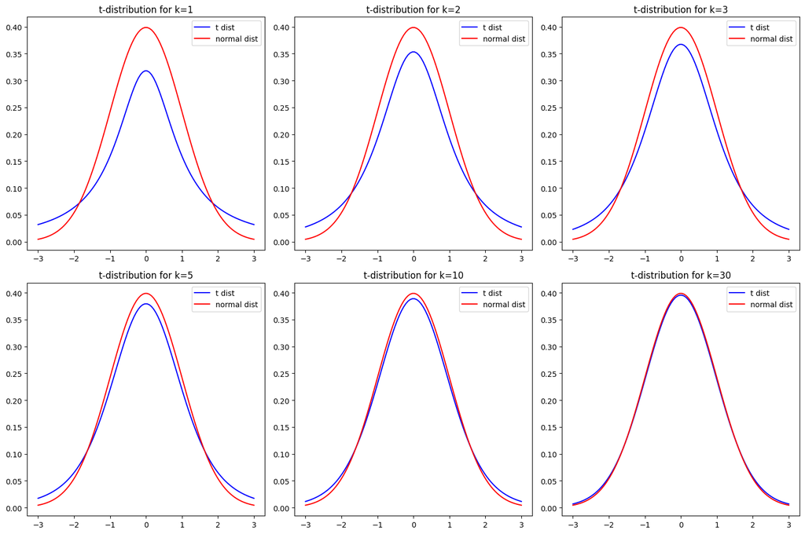

```python
# import the required function
from scipy.stats import t
from scipy.stats import norm

# set the values for x
x = np.linspace(-3, 3, 100)

# plot the t distribution for different values of k
fig, axes = plt.subplots(2, 3, sharex=False, sharey=False, figsize=(15, 10))
#ravel() functions returns contiguous flattened array(1D array with all the input-array
#elements and with the same type as it
axes = axes.ravel()
for i, k in zip(range(6), [1, 2, 3, 5, 10, 30]):
    ax = axes[i]
    ax.plot(x, t.pdf(x, df=k), color="blue", label="t dist")
    ax.plot(x, norm.pdf(x), color="red", label="normal dist")
    ax.set_title("t-distribution for k={0}".format(k))
    ax.legend(loc="upper right", fontsize=10)
plt.tight_layout()
```

Let's use the t-distribution to construct the confidence interval for the mean when population standard deviation is unknown.

The caffeine content (in mg) was examined for a random sample of 50 cups of black coffee dispensed by a new machine. The mean of the sample is found to be 110 mg and the sample standard deviation is estimated to be 7 mg. Construct a 95% confidence interval for μ, the mean caffeine content for cups dispensed by the machine.

```python
# import the required function
from scipy.stats import t

# set the values of sample mean and sample standard deviation
x_bar, s = 110, 7

# set the value of sample size and degrees of freedom
n = 50
k = n - 1

# construct the confidence interval
np.round(t.interval(0.95, df=k, loc=x_bar, scale=s / np.sqrt(n)), 2)
```

```
array([108.01, 111.99])
```